# 15 Patients: SAT and VAT Bland-Altman Plots

2021-06-14

## The original measurements from the Excel file

| PATIENT | SAT_KM1 | SAT_KM2 | SAT_MP1 | VAT_KM1 | VAT_KM2 | VAT_MP1 |
| --- | --- | --- | --- | --- | --- | --- |
| 1264707 | 62.07775 | 61.63525 | 62.011 | 35.5875 | 35.40375 | 35.10325 |
| 1553452 | 25.4414285714286 | 25.7002857142857 | 25.458 | 20.2628571428571 | 21.0451428571429 | 21.5357142857143 |
| 1610908 | 56.66 | 56.79575 | 56.67775 | 21.9865 | 21.80375 | 21.7505 |
| 1676769-2015 | 42.545 | 42.73475 | 42.74 | 25.23775 | 24.94525 | 25.66575 |
| 1695380 | 70.966 | 71.1248571428571 | 71.072 | 48.4122857142857 | 48.386 | 47.7514285714286 |
| 1772290 | 43.5365 | 43.5365 | 43.68725 | 39.20475 | 38.50125 | 38.7885 |
| 1762668 | 37.2345 | 37.3465 | 37.45275 | 31.20975 | 31.32175 | 34.02425 |
| 2026715 | 87.871 | 87.76525 | 87.943 | 52.80475 | 54.29375 | 53.80725 |
| 158894-2018 | 204.234 | 204.246666666667 | 203.952666666667 | 120.163555555556 | 120.502444444444 | 119.556222222222 |
| 389728 | 184.542222222222 | 183.675333333333 | 184.187777777778 | 117.201333333333 | 118.150222222222 | 115.907555555556 |

[output cut: 5 more lines]

The original data is reformatted from the **wide format** to, easily programmable, the **long format**. The table below shows how it looks like.

| PATIENT | FAT | OBSERVER | MEASUREMENT | VALUE |
| --- | --- | --- | --- | --- |
| 1264707 | SAT | KM | 1 | 62.07775 |
| 1553452 | SAT | KM | 1 | 25.4414285714286 |
| 1610908 | SAT | KM | 1 | 56.66 |
| 1676769-2015 | SAT | KM | 1 | 42.545 |
| 1695380 | SAT | KM | 1 | 70.966 |
| 1772290 | SAT | KM | 1 | 43.5365 |
| 1762668 | SAT | KM | 1 | 37.2345 |
| 2026715 | SAT | KM | 1 | 87.871 |
| 158894-2018 | SAT | KM | 1 | 204.234 |
| 389728 | SAT | KM | 1 | 184.542222222222 |

[output cut: 80 more lines]

Before plotting, we extract data to be plotted in the convenient format.

The table below shows this format for KM and MP observers and the 1st measurements. Note, that column names are fixed in the code.

| ID | MEAN | Y |
| --- | --- | --- |
| 1264707 | 62.044375 | 0.066749999999999 |
| 1553452 | 25.4497142857143 | -0.0165714285713996 |
| 1610908 | 56.668875 | -0.0177500000000066 |
| 1676769-2015 | 42.6425 | -0.195 |
| 1695380 | 71.019 | -0.106000000000009 |
| 1772290 | 43.611875 | -0.150750000000002 |
| 1762668 | 37.343625 | -0.218250000000005 |
| 2026715 | 87.907 | -0.0720000000000027 |
| 158894-2018 | 204.093333333334 | 0.281333333333009 |
| 389728 | 184.365 | 0.354444444443999 |

[output cut: 5 more lines]

## Bland-Altman plots for SAT segmentations

First, compute the Shapiro-Wilk tests for the pairs: KM1 and KM2, KM1 and MP1, KM2 and MP1.

```
##
##  Shapiro-Wilk normality test
##
## data:  sat_km1_km2$Y
## W = 0.85, p-value = 0.02
```

```
##
##  Shapiro-Wilk normality test
##
## data:  sat_km1_mp1$Y
## W = 0.93, p-value = 0.2
```

```
##
##  Shapiro-Wilk normality test
##
## data:  sat_km2_mp1$Y
## W = 0.91, p-value = 0.1
```

Note that, in the KM1 and KM2 measurements the null hypothesis is rejected on the significance level 0.1.

So, there is evidence that the data tested are not normally distributed on the significance level 0.1.

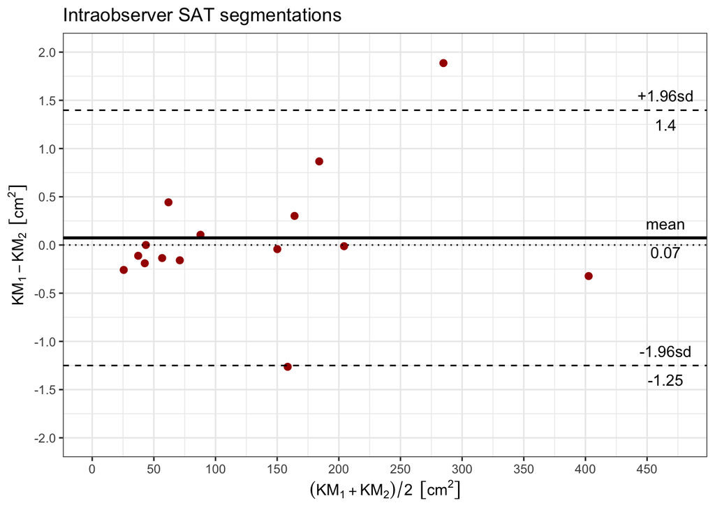

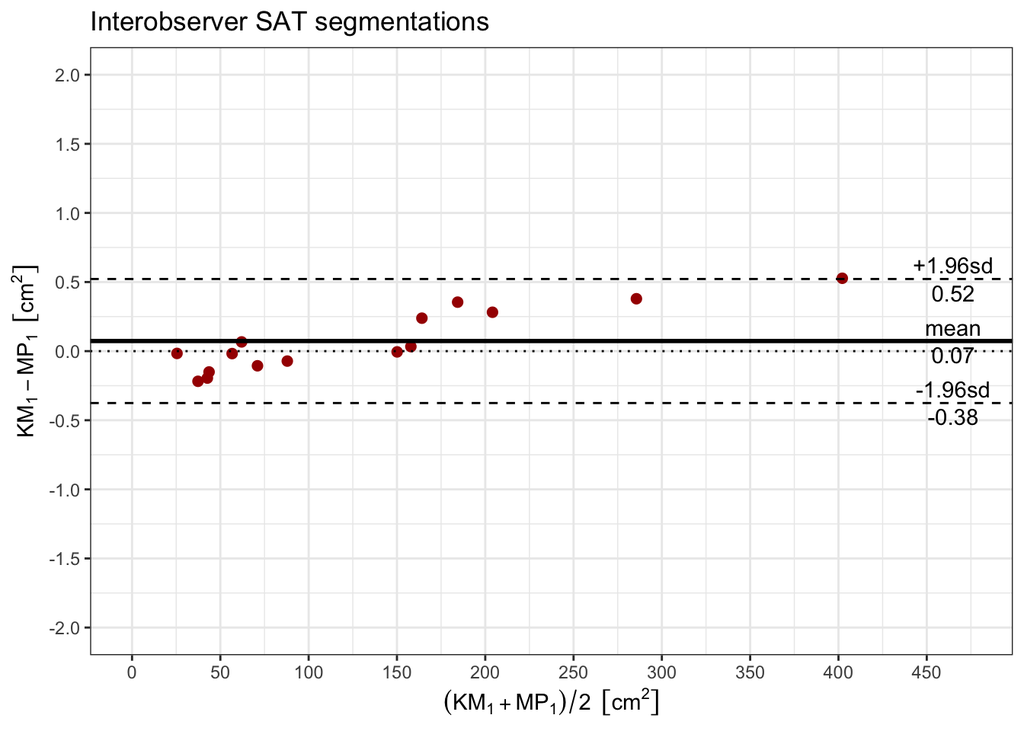

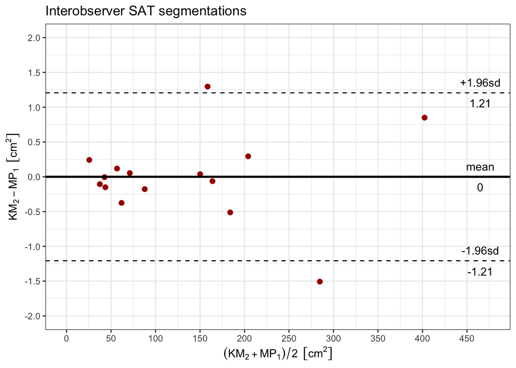

## Bland-Altman plots for VAT segmentations

First compute the Shapiro-Wilk tests for the pairs: KM1 and KM2, KM1 and MP1, KM2 and MP1.

```
##
##  Shapiro-Wilk normality test
##
## data:  vat_km1_km2$Y
## W = 0.98, p-value = 0.9
```

```
##
##  Shapiro-Wilk normality test
##
## data:  vat_km1_mp1$Y
## W = 0.95, p-value = 0.6
```

```
##
##  Shapiro-Wilk normality test
##
## data:  vat_km2_mp1$Y
## W = 0.9, p-value = 0.1
```

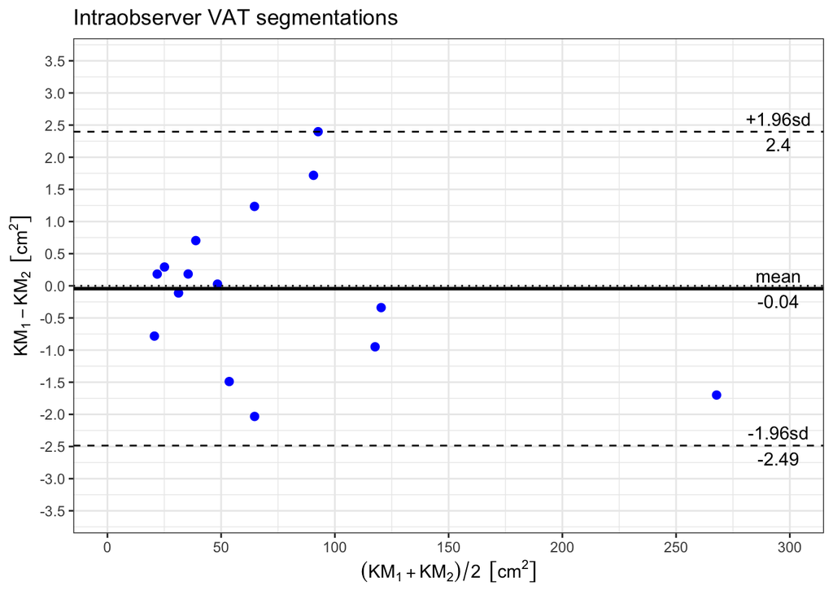

[figure not shown]

[figure not shown]

## Dlaczego różnica pomiarów ma mieć rozkład normalny?

Bo tak zwykle bywa z błędem pomiaru. A z różnicą (statystycznie) niezależnych pomiarów to tym bardziej tak będzie.

## Shapiro-Wilk *variance* test for normality

> After a study is completed, the investigator uses statistical tests to try to reject the null hypothesis in favor of its alternative (much in the same way that a prosecuting attorney tries to convince a judge to reject innocence in favor of guilt).  
> *Source*: [Hypothesis testing, type I and type II errors](https://www.ncbi.nlm.nih.gov/pmc/articles/PMC2996198/)

The probability of committing a type I error, **rejecting the null hypothesis when it is actually true**, is called α (alpha). The other name for this is the level of statistical significance.

The probability of making a type II error, **failing to reject the null hypothesis when it is actually false** is called β (beta).

The null-hypothesis (hipoteza zerowa, $H_0$) of the Shapiro–Wilk test is that the data came from a normally distributed variable.

1. Thus, if the $p\hbox{-value} < \alpha$, then the null hypothesis is rejected and there is evidence that the data tested are not normally distributed.
2. On the other hand, if the $p\hbox{-value} > \alpha$, then the null hypothesis (the sample came from a normally distributed population) can not be rejected.

### Establishing, *in advance*, the maximum chances of errors

The investigator establishes the maximum chance of making type I and type II errors in advance of the study.

Nam zależy, aby błąd pierwszego rodzaju (type I) był nieduży (odrzucenie hipotezy zerowej, kiedy jest ona w rzeczywistości prawdziwa). Błąd ten nazywamy α (alpha, the level of statistical significance).

Dla naszych danych o liczebności próby $n = 15$ wybieramy significance level (*poziom istotności*) $\alpha = 0{⋅}1$.

### Przykładowe rachunki w R

```r
sort(sat_km1_km2$Y)
```

```
##  [1] -1.26325 -0.32240 -0.25886 -0.18975 -0.15886 -0.13575 -0.11200 -0.04325
##  [9] -0.01267  0.00000  0.10575  0.30125  0.44250  0.86689  1.88622
```

```r
shapiro.test(sat_km1_km2$Y)
```

```
##
##  Shapiro-Wilk normality test
##
## data:  sat_km1_km2$Y
## W = 0.85, p-value = 0.02
```

Jeśli pominiemy w danych `sat_km1_km2$Y` trzy wartości nietypowe (*outliers*), pierwszą i dwie ostatnie, to wynikiem testu będzie:

```r
new_sat_table
```

```
##  [1] -0.32240 -0.25886 -0.18975 -0.15886 -0.13575 -0.11200 -0.04325 -0.01267
##  [9]  0.00000  0.10575  0.30125  0.44250
```

```r
shapiro.test(new_sat_table)
```

```
##
##  Shapiro-Wilk normality test
##
## data:  new_sat_table
## W = 0.92, p-value = 0.3
```

Tym razem na poziomie istotności $0{⋅}1$ nie podstaw do odrzucenia hipotezy, że dane pochodzą z próby o rozkładzie normalnym.

### Podsumowanie

1. Jeśli $p\hbox{-value} < \alpha$, to na danym poziomie istotności $\alpha$ odrzucamy hipotezę zerową.
2. Jeśli $p\hbox{-value} > \alpha$, to na danym poziomie istotności $\alpha$ nie ma podstaw do odrzucenia hipotezy zerowej.

### A co z błędami drugiego rodzaju (type II)

Jak wyglądałoby testowanie, gdybyśmy ustalili parametr α = 0⋅00000000001?

### Jaki jest sens parametru $W$ w wynikach testu

Proponuję zajrzeć do artykułu autorów testu, S. S. Shapiro, M. B. Wilk. [An analysis of variance test for normality (complete samples)](http://webspace.ship.edu/pgmarr/Geo441/Readings/Shapiro%20and%20Wilk%201965%20-%20An%20Analysis%20of%20Variance%20Test%20for%20Normality.pdf) 1965 (liczba cytowań to 18824) na stronę z Table 6, oraz na następną stronę z przeliczonym przykładem.

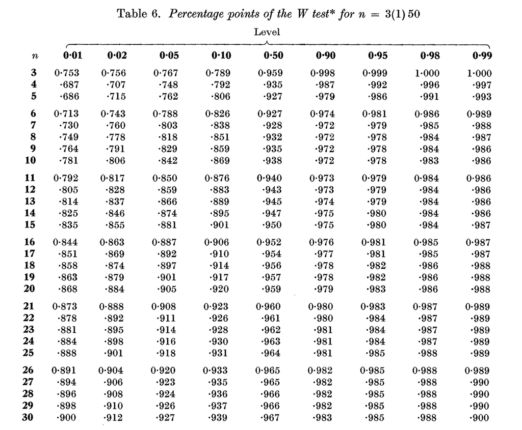

Table 6. Percentage points of the W test

### Zazywyczaj sam test to za mało…

Należy dołączyć jakieś wykresy. Dla testu Shapiro-Wilka sugerowane jest narysowanie histogramu z nałożonym wykresem gęstości rozkładu normalnego, lub wykresy dystrybuant, zob. Figure 4 w artykule Davida Giavarina, [Understanding Bland Altman analysis](https://www.ncbi.nlm.nih.gov/pmc/articles/PMC4470095/) oraz tekst pod Figure 4.

Ja proponuję wykresy dystrybuant, tzw. ECDF, *Empirical Cumulative Distribution Functions*.

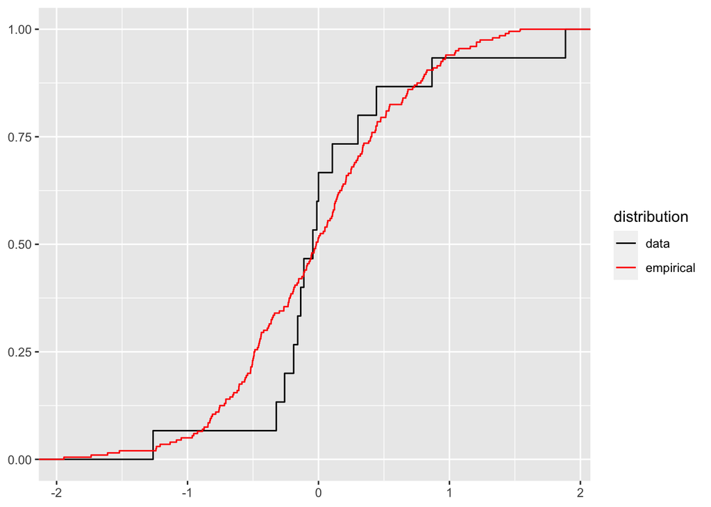